# Logistic Regression for Loansharks (2015 Pennsylvania)

# Model with census data integrated.

```r
# https://www2.census.gov/programs-surveys/popest/datasets/2010-2018/counties/asrh/
census_pa_file_path <- paste(census_data_dir, sep = "", "/cc-est2018-alldata-42.csv")

merged_hmda_data_df_for_model <- merge_hmda_df_with_census(census_pa_file_path, hmda_data_df_for_model)

split_dfs <- train_test_split(merged_hmda_data_df_for_model$loan_granted, merged_hmda_data_df_for_model)

merged_train <- split_dfs[[1]]
merged_test <- split_dfs[[2]]

merged_2015_model <- build_glm_model("loan_granted~applicant_race_and_ethnicity+owner_occupancy+preapproval+property_type+log_loan_amount_000s+tract_to_msamd_income+co_applicant_present+agency_code+BLACK_PERCENT+ASIAN_PERCENT+HISPANIC_PERCENT+county_code+respondent_id+applicant_sex+loan_purpose+loan_to_income_ratio", merged_train)

model5_fitted.probs <- predict(merged_2015_model, merged_test, type = "response")

writeLines("")
```

```r
writeLines("Merged model performance")
```

```
Merged model performance
```

```
[1] "no"  "yes"
[1] "Accuracy 0.75647982928938"
Confusion Matrix and Statistics

          Reference
Prediction    no   yes
       no   7350  5086
       yes  8152 33773

               Accuracy : 0.7565
                 95% CI : (0.7528, 0.7601)
    No Information Rate : 0.7148
    P-Value [Acc > NIR] : < 0.00000000000000022

                  Kappa : 0.3649

 Mcnemar's Test P-Value : < 0.00000000000000022

            Sensitivity : 0.8691
            Specificity : 0.4741
         Pos Pred Value : 0.8056
         Neg Pred Value : 0.5910
             Prevalence : 0.7148
         Detection Rate : 0.6213
   Detection Prevalence : 0.7712
      Balanced Accuracy : 0.6716

       'Positive' Class : yes

Confusion Matrix and Statistics

          Reference
Prediction    no   yes
       no   7350  5086
       yes  8152 33773

               Accuracy : 0.7565
                 95% CI : (0.7528, 0.7601)
    No Information Rate : 0.7148
    P-Value [Acc > NIR] : < 0.00000000000000022
```

[output cut: 11 more lines]

```
   Detection Prevalence : 0.7712
      Balanced Accuracy : 0.6716

       'Positive' Class : yes

[1] "Precision not found"
[1] "Prevalence"
[1] "Precision and Recall"
[1] 0.8055575
[1] 0.8691165
[[1]]
[1] 0.8055575

[[2]]
[1] 0.8691165
```

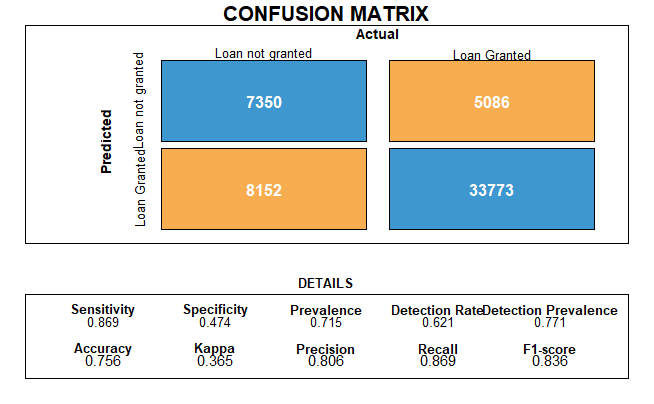

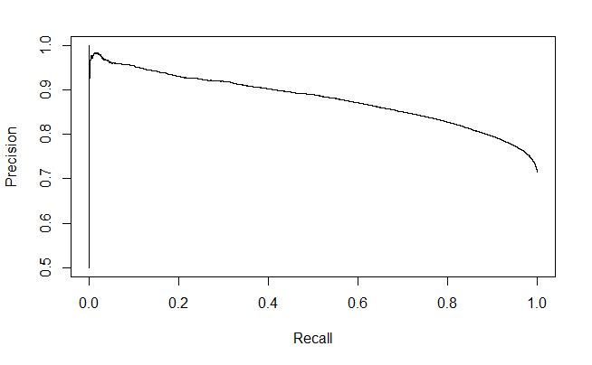

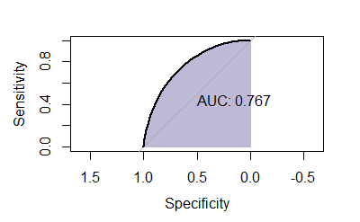

```r
print_model_performance(model5_fitted.probs, merged_test, positive = "yes", negative = "no", threshold = 0.6)
```

# Loan to value ratio is an important metric which banks use to decide

# whether a loan should be granted or not. For e.g. the higher the loan

# to value ratio the riskier it is for the bank.

# https://en.wikipedia.org/wiki/Loan-to-value_ratio

# Banks are not required to report this metric in the HMDA reporting

# law. We use the median of the home values in that county based on

# data available from zillow https://www.zillow.com/research/data/

```r
period_list <- c("2015-01", "2015-02", "2015-03", "2015-04",
                 "2015-05", "2015-06", "2015-07", "2015-08",
                 "2015-09", "2015-10", "2015-11", "2015-12")

merged_hmda_with_loan_to_value_ratio <- augment_hmda_data_with_estimated_loan_to_value_ratio_from_zillow(paste(data_dir, "/zillow/counties_home_value_per_year.csv", sep = ""), hmda_data_df_for_model, "PA", period_list)
```

```
 [1] "2015-01"    "2015-02"    "2015-03"    "2015-04"    "2015-05"
 [6] "2015-06"    "2015-07"    "2015-08"    "2015-09"    "2015-10"
[11] "2015-11"    "2015-12"    "RegionName"
```

```r
head(merged_hmda_with_loan_to_value_ratio)
```

|  | county_name | applicant_race_and_ethnicity | applicant_income_000s | co_applicant_race_and_ethnicity | co_applicant_sex | hoepa_status | lien_status | msamd | owner_occupancy | preapproval | purchaser_type | property_type | loan_amount_000s | applicant_sex | hud_median_family_income | tract_to_msamd_income | loan_to_income_ratio | agency_code | minority_population | loan_purpose | rate_spread | population | number_of_owner_occupied_units | loan_granted | log_loan_amount_000s | log_applicant_income_000s | credit_score | co_applicant_present | respondent_id | … |
| --- | --- | --- | --- | --- | --- | --- | --- | --- | --- | --- | --- | --- | --- | --- | --- | --- | --- | --- | --- | --- | --- | --- | --- | --- | --- | --- | --- | --- | --- | --- |
| 1 | Adams County | White | 90 | White | 2 | 2 | 1 | 23900 | 1 | 3 | 1 | 1 | 174 | 1 | 75100 | 96.06 | 1.9333333 | 9 | 10.83 | 1 | 2.06 | 5829 | 1766 | yes | 5.159055 | 4.499810 | 734 | 1 | 0000451965 | … |
| 2 | Adams County | White | 89 | White | 2 | 2 | 1 | 23900 | 1 | 3 | 6 | 1 | 82 | 1 | 75100 | 95.31 | 0.9213483 | 5 | 7.17 | 3 | 1.50 | 7451 | 2387 | yes | 4.406719 | 4.488636 | 734 | 1 | 0000006694 | … |
| 3 | Adams County | White | 115 | No co-applicant | 5 | 2 | 1 | 23900 | 1 | 3 | 0 | 1 | 226 | 1 | 75100 | 129.68 | 1.9652174 | 9 | 6.40 | 3 | 1.59 | 3670 | 1275 | yes | 5.420535 | 4.744932 | 734 | 0 | 0000817824 | … |
| 4 | Adams County | White | 62 | No co-applicant | 5 | 2 | 1 | 23900 | 1 | 3 | 1 | 1 | 127 | 2 | 75100 | 110.39 | 2.0483871 | 9 | 11.22 | 3 | 2.66 | 3975 | 1215 | yes | 4.844187 | 4.127134 | 734 | 0 | 0002590037 | … |
| 5 | Adams County | White | 36 | No co-applicant | 5 | 2 | 1 | 23900 | 1 | 3 | 0 | 1 | 43 | 2 | 75100 | 104.31 | 1.1944444 | 5 | 12.33 | 3 | 1.50 | 7300 | 1987 | yes | 3.761200 | 3.583519 | 734 | 0 | 0000006694 | … |
| 6 | Adams County | White | 34 | No co-applicant | 5 | 2 | 1 | 23900 | 1 | 3 | 0 | 1 | 124 | 2 | 75100 | 113.53 | 3.6470588 | 9 | 3.78 | 3 | 6.26 | 2700 | 858 | yes | 4.820282 | 3.526361 | 734 | 0 | 0000817824 | … |

```r
NA
```

# Train test split on the hmda dataset merged with estimated loan to value

# ratio

```r
split_dfs <- train_test_split(merged_hmda_with_loan_to_value_ratio$loan_granted, merged_hmda_with_loan_to_value_ratio)
new_train <- split_dfs[[1]]
new_test <- split_dfs[[2]]
```

## Model with estimated loan to value ratio.

```
Model summary


Call:
glm(formula = as.formula(model_formula), family = binomial(link = "logit"),
    data = train_df, control = glm.control(maxit = iter))

Deviance Residuals:
    Min       1Q   Median       3Q      Max
-3.5622  -0.7293   0.5134   0.7644   5.7813

Coefficients:
                                                                                                                Estimate
(Intercept)                                                                                                    0.6905315
applicant_race_and_ethnicityAsian                                                                              0.5789517
applicant_race_and_ethnicityBlack or African American                                                          0.1746564
applicant_race_and_ethnicityHispanic or Latino                                                                 0.2014293
applicant_race_and_ethnicityInformation not provided by applicant in mail, Internet, or telephone application  0.3807433
applicant_race_and_ethnicityNative Hawaiian or Other Pacific Islander                                          0.3134609
applicant_race_and_ethnicityNot applicable                                                                     0.4477212
applicant_race_and_ethnicityWhite                                                                              0.7658866
owner_occupancy2                                                                                              -0.0860687
owner_occupancy3                                                                                              -0.1297146
preapproval2                                                                                                  -0.4051030
preapproval3                                                                                                  -0.5902261
log_loan_amount_000s                                                                                           0.0301055
applicant_sex2                                                                                                -0.0636522
applicant_sex3                                                                                                 0.0477196
applicant_sex4                                                                                                 1.3471240
county_code11                                                                                                 -0.1067976
county_code125                                                                                                 0.1626485
county_code129                                                                                                 0.1910260
county_code133                                                                                                 0.0094747
county_code17                                                                                                  0.2169130
county_code19                                                                                                  0.2339151
county_code21                                                                                                 -0.0207856
county_code27                                                                                                  0.4715996
county_code29                                                                                                  0.3363442
county_code3                                                                                                   0.1818250
county_code41                                                                                                  0.2030413
```

[output cut: 550 more lines]

```
log_loan_amount_000s         < 0.00000000000000022 ***
applicant_sex                < 0.00000000000000022 ***
county_code                  < 0.00000000000000022 ***
tract_to_msamd_income        < 0.00000000000000022 ***
co_applicant_present         < 0.00000000000000022 ***
agency_code                  < 0.00000000000000022 ***
minority_population          < 0.00000000000000022 ***
loan_to_income_ratio         < 0.00000000000000022 ***
loan_purpose                 < 0.00000000000000022 ***
rate_spread                  < 0.00000000000000022 ***
property_type                < 0.00000000000000022 ***
loan_to_value_ratio                  0.00000397900 ***
respondent_id                < 0.00000000000000022 ***
---
Signif. codes:  0 ‘***’ 0.001 ‘**’ 0.01 ‘*’ 0.05 ‘.’ 0.1 ‘ ’ 1
```

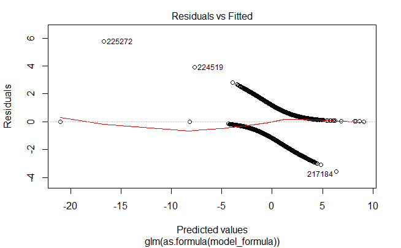

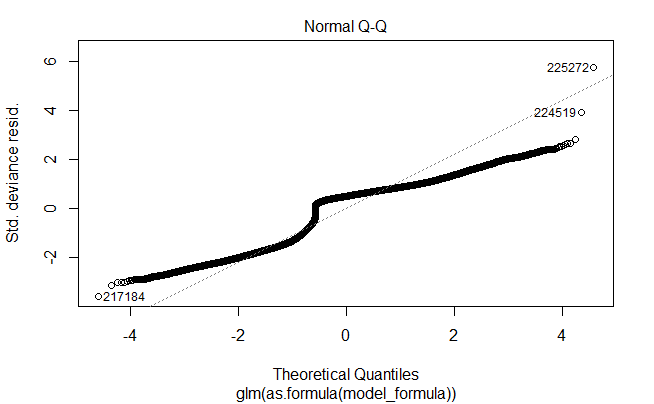

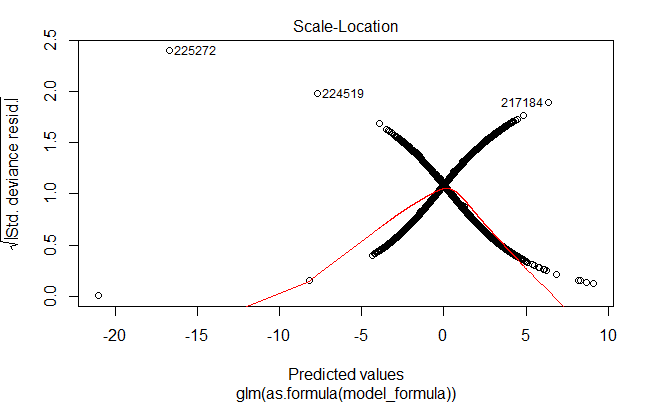

```
optimal cut threshold is
                 [,1]
sensitivity 0.7000219
specificity 0.6969780
cutoff      0.7238058
```

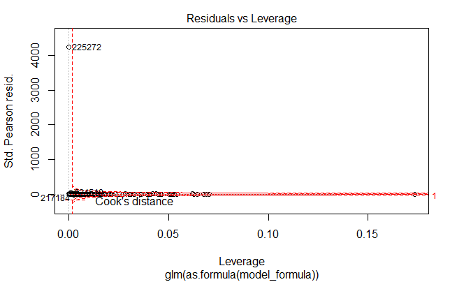

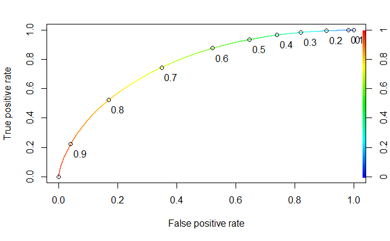

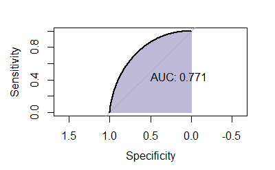

```r
model_2015_with_loan_to_value_ratio <-
build_glm_model("loan_granted~applicant_race_and_ethnicity+owner_occupancy+preapproval+log_loan_amount_000s+applicant_sex+county_code+tract_to_msamd_income+co_applicant_present+agency_code+minority_population+loan_to_income_ratio+loan_purpose+rate_spread+property_type+loan_to_value_ratio+respondent_id", new_train)

model_summary_and_plot(model_2015_with_loan_to_value_ratio, train = new_train)
```

```r
mcfadden_r_square(model_2015_with_loan_to_value_ratio, null_model)
```

```
Mcfadden Rsquare value
'log Lik.' 0.175587 (df=106)
```

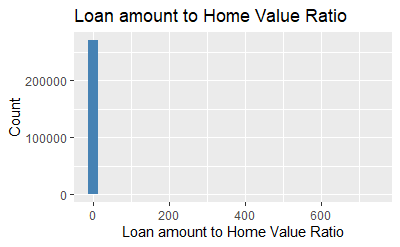

```r
ggplot(data = merged_hmda_with_loan_to_value_ratio, aes(x=loan_to_value_ratio)) +geom_histogram(fill = "steelblue") + labs(title = "Loan amount to Home Value Ratio" , x = "Loan amount to Home Value Ratio",y="Count")
```

```r
model6_fitted.probs <- predict(model_2015_with_loan_to_value_ratio, new_test, type = "response")

writeLines("")
```

```r
writeLines("Model with estimated loan to value ratio performance")
```

```
Model with estimated loan to value ratio performance
```

```
[1] "no"  "yes"
[1] "Accuracy 0.762421589006825"
Confusion Matrix and Statistics

          Reference
Prediction    no   yes
       no   7393  4806
       yes  8109 34053

               Accuracy : 0.7624
                 95% CI : (0.7588, 0.766)
    No Information Rate : 0.7148
    P-Value [Acc > NIR] : < 0.00000000000000022

                  Kappa : 0.3774

 Mcnemar's Test P-Value : < 0.00000000000000022

            Sensitivity : 0.8763
            Specificity : 0.4769
         Pos Pred Value : 0.8077
         Neg Pred Value : 0.6060
             Prevalence : 0.7148
         Detection Rate : 0.6264
   Detection Prevalence : 0.7756
      Balanced Accuracy : 0.6766

       'Positive' Class : yes

Confusion Matrix and Statistics

          Reference
Prediction    no   yes
       no   7393  4806
       yes  8109 34053

               Accuracy : 0.7624
                 95% CI : (0.7588, 0.766)
    No Information Rate : 0.7148
    P-Value [Acc > NIR] : < 0.00000000000000022
```

[output cut: 11 more lines]

```
   Detection Prevalence : 0.7756
      Balanced Accuracy : 0.6766

       'Positive' Class : yes

[1] "Precision not found"
[1] "Prevalence"
[1] "Precision and Recall"
[1] 0.8076704
[1] 0.8763221
[[1]]
[1] 0.8076704

[[2]]
[1] 0.8763221
```

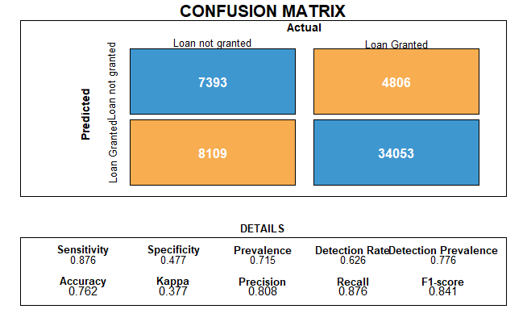

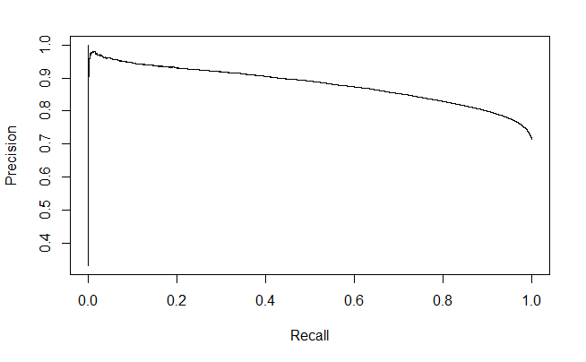

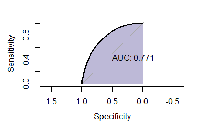

```r
print_model_performance(model6_fitted.probs, new_test, positive = "yes", negative = "no", threshold = 0.6)
```

# Save the models

```r
dir.create(model_path, showWarnings = FALSE)
save(model_2015_income_loan_amount, file = paste(model_path, "/model_income_loan_amount.rdata", sep=""))
save(model_2015_log_income_loan_amount, file = paste(model_path, "/model_log_income_loan_amount.rdata", sep=""))
save(model_2015_ratio_of_loan_to_income_with_log_of_income_and_amount, file = paste(model_path, "/model_loan_income_ratio_with_log_of_income_and_amount.rdata", sep=""))
save(model_2015_cross_val_loan_income_ratio, file = paste(model_path, "/cross_val_model.rdata", sep=""))
save(merged_2015_model, file = paste(model_path, "/merged_model.rdata", sep=""))

save(model_2015_with_loan_to_value_ratio, file = paste(model_path, "/merged_model_with_loan_to_value.rdata", sep=""))
```

# Save the train and test data for future reference.

```r
dir.create(model_data_path, showWarnings = FALSE)
save(train, file = paste(model_data_path, "/train.rdata", sep = ""))
save(test, file = paste(model_data_path, "/test.rdata", sep = ""))

dir.create(model_data_path, showWarnings = FALSE)
save(merged_train, file = paste(model_data_path, "/merged_train.rdata", sep = ""))
save(merged_test, file = paste(model_data_path, "/merged_test.rdata", sep = ""))

dir.create(model_data_path, showWarnings = FALSE)
save(new_train, file = paste(model_data_path, "/train_with_loan_to_value.rdata", sep = ""))
save(new_test, file = paste(model_data_path, "/test_with_loan_to_value.rdata", sep = ""))
```